# Intro to Markdown Basics and LaTeX

## September 2020

### Baldomero Pena

The purpose of this document is to cover in a brief and concise manner the basic commands for regular text and math symbols.  
Therefore, we divide the file in 2 parts:

- Markdown Basics
- LATEX Mathematical Symbols

Please note at the bottom of this document the references are available for installation and further exploration.

## Markdown Basics

**Hello Wolrd!**  
*How are you?*

The pourpose of this text is to **show already some *commands*** while you are reading this. it.  
You can always edit the text by double clicliking on the cell.  
Then, as usual, shift+enter

So far

we just

saw:  
***  
_**___**  
--------

1. Headings
2. Line Break
3. Paragraph
4. Mark emphasis
   - *Italics*
   - **Bold**
   - **Combined *emphasis***
   - Striketrough.
5. Horizontal rule
   - (***)
   - (___)
   - (---)

And you just saw a list, and below another one with the content to follow:

- Markdown Basics
  - Tables
  - Inserted Variables
- LaTeX
  - Greek letters
  - Math constructs
    - fractions
    - overline
    - overarrow
  - Combo
    - Symbols
    - Standard Function Names
    - Functions
    - Binary Operation Symbols
    - Array environment

#### Tables

Let's start building it from the scratch...

| Stretch/Untouched | ProbDistribution | Accuracy |

If we play with the horizontal line we can start to build the table...

| Stretch/Untouched | ProbDistribution | Accuracy | | --- | --- | --- |

to obtain...

| Stretch/Untouched | ProbDistribution | Accuracy |
| --- | --- | --- |
| Stretched | Gaussian | .843 |

and we can go on...

| Rank | Name | Surname | Restaurant |
| --- | --- | --- | --- |
| 1 | Albert | Adria | Tickets |
| 2 | Grant | Achatz | Alinea |
| 3 | Anand | Gaggan | Gaggan |
| 4 | Alex | Atala | D.O.M |
| 5 | René | Redzepi | Noma |

#### Inserted Variables

We can include the output results of the code in markdown

```python
winner = 'albert'
print(winner)
```

```
albert
```

And the winner is albert

```python
from IPython.display import display, Markdown, Latex
```

```python
latextrailer = Latex(r'$𝑑𝑆_𝑡=𝑟𝑆_𝑡𝑑𝑡 + σ𝑆_𝑡𝑑𝑍_𝑡$')
```

A lovely formula to remember $𝑑𝑆_𝑡=𝑟𝑆_𝑡𝑑𝑡 + σ𝑆_𝑡𝑑𝑍_𝑡$

We can also include images, which is useful to show you below

```python
from IPython.display import Image, SVG
```

```python
a = Image(filename='configurable nbextensions.jpg')
```

**Please be aware of the first potential problem after installing....**

[figure not shown]

```python
b = Image(filename='configurable nbextensions -solved.jpg')
```

A **solution** to this problem may be resolved by typing in Anaconda Prompt below  
pip install jupyter_contrib_nbextensions && jupyter contrib nbextension install  
...and after reopening Jupyter Notebook....

[figure not shown]

```python
c = Image(filename='Enable Python Markdown.jpg')
```

**Once solved**, to do what you have just seen in Inserted Variables,  
Click on **Edit** and at bottom click on *nbextensions config*.  
Then, enable **Python Markdown**.

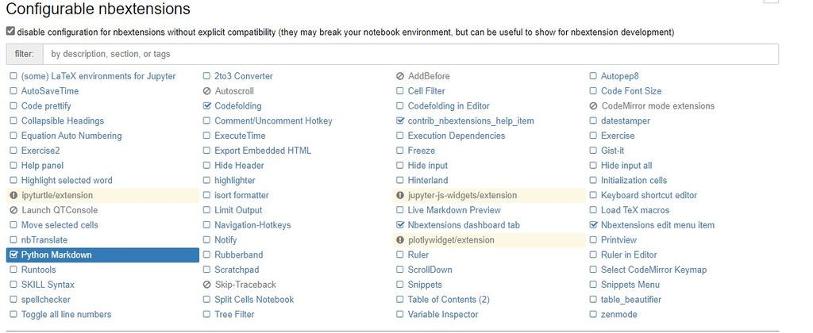

And then you will be ready to announce that the winner is albert

Please note that if you go to File, Download as pdf or html is quite probable you wont render any of the variables you saw before at Inserted Variables.  
However, we can use nbconvert to avoid this problem. Use anaconda prompt, move to the directoy your file is locate and type (i.e for html):  
jupyter nbconvert --to html --CodeFoldingPreprocessor.remove_folded_code=True mynotebokename.ipynb

**How it would like:**

Initial screen  
C:\Users\UserName>

You move to the folder where the file is located  
C:\Users\UserName>CD Desktop\CQF\Projectfolder

Now you are located in the folder  
C:\Users\UserName\Desktop\CQF\Projectfolder>

You can type and convert, it should appear in the same folder in the converted format (html in this case)

C:\Users\UserName\Desktop\CQF\Projectfolder> jupyter nbconvert --to html --CodeFoldingPreprocessor.remove_folded_code=True mynotebokename.ipynb

## LaTex for Maths

### Greek Letters

$ \alpha $ $\beta$ $$\chi$$ $$ \eta $$ $\delta$ and $\Delta$ $$\gamma$$ and $$\Gamma$$

$$\phi$$

and

$$\Phi$$ $$\pi$$ $$and$$ $$\Pi$$

### Math Constructs

$\frac{4}{2}$ $$ \sqrt{42x} $$ $ \sqrt[4]{42x} $

$$ \sqrt[2]{(x_2 - x_1)^{2} + (y_2 - y_1)^{2}} $$

the vector $\overline{v}$  
and the vector $\overrightarrow{u}$

### Combo

Newton's method: $$ y= \dfrac{(x + a/x)}{2} $$

Stochastic differential equation (SDE): $$ 𝑑𝑆_𝑡=𝑟𝑆_𝑡𝑑𝑡 + σ𝑆_𝑡𝑑𝑍_𝑡 $$
Applying Euler discretization of SDE: $$ 𝑆_𝑡=𝑆_{𝑡−Δ𝑡}𝑒𝑥𝑝^{((𝑟−\frac{1}{2}𝜎^2)Δ𝑡+𝜎\sqrt[2]{Δ𝑡}𝑧𝑡)} $$

A vector:

$ \vec{v} = \left(\begin{array}{c} 1 \\ 2 \\ . \\ . \\ . \\ 100 \end{array} \right) $

The scalar multiplication of this vector:

$ \vec{u}=2\cdot \vec{v} = \left(\begin{array}{c} 2 \\ 4 \\ . \\ . \\ . \\ 200 \end{array} \right) $

$ \left(\begin{array}{ccc} 2&4&6 \\ 8&10&12 \\ \end{array} \right) $

$\left[ \begin{array}{ccc|r} 2 & 4 & 6 & 42 \\ 1 & 3 & 5 & 11 \\ 5 & 11 & 13 & 1764 \end{array} \right]$

$$ sign(x) = \left\{ \begin{array}\\ 1 & \mbox{if } \ x \in \mathbf{N}^* \\ 0 & \mbox{if } \ x = 0 \\ -1 & \mbox{else} \end{array} \right. $$

$$ N(x) = \frac{1}{\sqrt{2\pi}}\int^{x}_{-\infty}e^{-\frac{1}{2}x^2}dx $$

$$ 𝐶_𝑇=𝑚𝑎𝑥(0,\frac{1}{𝑇}\sum_{i=1}^{T}𝑆_𝑖−𝐾) $$

$$ \frac{\partial V}{\partial t} = \lim_{h\rightarrow0}\frac{V(S, t + h) - V(S,t)}{h} $$

$$ \frac{\partial V}{\partial t}(S,t) \approx \frac{V^k_i - V^{k+1}_i}{\delta t} $$

$$ \frac{\partial V}{\partial t}+ \frac{1}{2}\sigma^2S^2\frac{\partial ^2V}{\partial S^2} +rs\frac{\partial V}{\partial S} - rV = 0 $$

$$ \Theta + \frac{1}{2} + \sigma^2S^2\Gamma + rS\Delta - rV = 0 $$

## References

- [Installation](https://www.latex-project.org/get/)
  - Useful links if your OS is Windows:
    - [Install nbconvert](https://nbconvert.readthedocs.io/en/latest/install.html)
    - [Install Miktex](https://miktex.org/download)
    - [Install XeLaTeX](http://www.texts.io/support/0002/)
- [Learn How to Write Markdown & LaTeX in The Jupyter Notebook](https://towardsdatascience.com/write-markdown-latex-in-the-jupyter-notebook-10985edb91fd)
- [Markdown Template with inserted variables](https://github.com/ipython-contrib/jupyter_contrib_nbextensions/tree/master/src/jupyter_contrib_nbextensions/nbextensions/python-markdown)
  - [Installation - Instructions](https://github.com/ipython-contrib/jupyter_contrib_nbextensions#installation)
  - [Installation - nbextensions configurator](https://github.com/Jupyter-contrib/jupyter_nbextensions_configurator)
  - [Exporting successfully to another format](https://jupyter-contrib-nbextensions.readthedocs.io/en/latest/exporting.html)
- [LaTeX Mathematical Symbols - useful pdf](https://www.caam.rice.edu/~heinken/latex/symbols.pdf)